# Practical_Machine_Learning_Course_Project

Bowen Wang

August 19, 2016

# Background and Goal

Nowadays, it is possible to collect a large amount of data about personal activity relatively inexpensively. These type of devices are part of the quantified self movement - a group of enthusiasts who take measurements about themselves regularly to improve their health, to find patterns in their behavior, or because they are tech geeks. One thing that people regularly do is quantify how much of a particular activity they do, but they rarely quantify how well they do it.

In this project, my goal is to use data from accelerometers on the belt, forearm, arm, and dumbell of 6 participants. They were asked to perform barbell lifts correctly and incorrectly in 5 different ways.

# Load the packages for reproducibility

```r
library(caret)
library(rpart)
```

```r
library(rpart.plot)
library(RColorBrewer)
library(rattle)
library(randomForest)
set.seed(12345)
```

# Getting the Data

The data for this project come from this source: http://groupware.les.inf.puc-rio.br/har. Specifically, the training data for this project are available here: https://d396qusza40orc.cloudfront.net/predmachlearn/pml-training.csv, and the test data are available here: https://d396qusza40orc.cloudfront.net/predmachlearn/pml-testing.csv.

```r
trainURL <- "http://d396qusza40orc.cloudfront.net/predmachlearn/pml-training.csv"
testURL <- "http://d396qusza40orc.cloudfront.net/predmachlearn/pml-testing.csv"
```

```r
training <- read.csv(url(trainURL), na.strings=c("NA","#DIV/0!",""))
testing <- read.csv(url(testURL), na.strings=c("NA","#DIV/0!",""))
```

Here, I divide the training set into two subsets, 60% as “myTraining” and 40% as “myTesting”:

```r
inTraining <- createDataPartition(y=training$classe, p=0.6, list=FALSE)
myTraining <- training[inTraining, ];
myTesting <- training[-inTraining, ]
```

# Cleaning the data

1. reduce the number of features by removing variables with nearly zero variance

```r
myTrainingNZV <- nearZeroVar(myTraining, saveMetrics=TRUE)
```

2. reduce the number of features by removing variables that make no intuitive sense for predictions

```r
myToRemove <- names(myTraining) %in% c("new_window", "kurtosis_roll_belt", "kurtosis_picth_belt",
"kurtosis_yaw_belt", "skewness_roll_belt", "skewness_roll_belt.1", "skewness_yaw_belt", "max_yaw_belt", "min_yaw_belt", "amplitude_yaw_belt", "avg_roll_arm", "stddev_roll_arm", "var_roll_arm", "avg_pitch_arm", "stddev_pitch_arm", "var_pitch_arm", "avg_yaw_arm", "stddev_yaw_arm", "var_yaw_arm", "kurtosis_roll_arm", "kurtosis_picth_arm", "kurtosis_yaw_arm", "skewness_roll_arm", "skewness_pitch_arm", "skewness_yaw_arm", "max_roll_arm", "min_roll_arm", "min_pitch_arm", "amplitude_roll_arm", "amplitude_pitch_arm", "kurtosis_roll_dumbbell", "kurtosis_picth_dumbbell", "kurtosis_yaw_dumbbell", "skewness_roll_dumbbell", "skewness_pitch_dumbbell", "skewness_yaw_dumbbell", "max_yaw_dumbbell", "min_yaw_dumbbell", "amplitude_yaw_dumbbell", "kurtosis_roll_forearm", "kurtosis_picth_forearm", "kurtosis_yaw_forearm", "skewness_roll_forearm", "skewness_pitch_forearm", "skewness_yaw_forearm", "max_roll_forearm", "max_yaw_forearm", "min_roll_forearm", "min_yaw_forearm", "amplitude_roll_forearm", "amplitude_yaw_forearm", "avg_roll_forearm", "stddev_roll_forearm", "var_roll_forearm", "avg_pitch_forearm", "stddev_pitch_forearm", "var_pitch_forearm", "avg_yaw_forearm", "stddev_yaw_forearm", "var_yaw_forearm")
Training1 <- myTraining[!myToRemove]
```

Remove first column of Dataset ID

```r
Training2 <- Training1[c(-1)]
```

3. Cleaning Variables with too many NAs at a 60% threshold of NA’s.

```r
Training3 <- Training2
for(i in 1:length(Training2))
  {
        if( sum( is.na( Training2[, i] ) ) /nrow(Training2) >= .6 )
          {
        for(j in 1:length(Training3))
          {
            if( length( grep(names(Training2[i]), names(Training3)[j]) ) ==1)
              {
                Training3 <- Training3[ , -j]
            }
        }
    }
}

Training2 <- Training3
rm(Training3)
```

Do the same 3 steps to the testing data sets

```r
clean1 <- colnames(Training2)
clean2 <- colnames(Training2[, -58]) #already with classe column removed
myTesting <- myTesting[clean1]
testing <- testing[clean2]
```

```r
for (i in 1:length(testing) )
  {
        for(j in 1:length(Training2))
          {
        if( length( grep(names(Training2[i]), names(testing)[j]) ) ==1)
          {
            class(testing[j]) <- class(Training2[i])
        }
    }
}

testing <- rbind(Training2[2, -58] , testing)
testing <- testing[-1,]
```

# Using ML algorithms for prediction: Decision Tree

```r
modFitA1 <- rpart(classe ~ ., data=Training2, method="class")
```

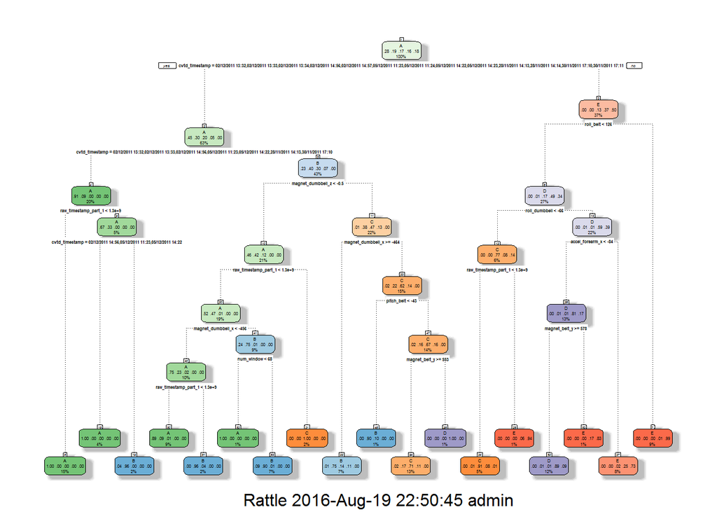

```r
fancyRpartPlot(modFitA1)
```

```r
predictionsA1 <- predict(modFitA1, myTesting, type = "class")
```

```r
confusionMatrix(predictionsA1, myTesting$classe)
```

```
## Confusion Matrix and Statistics
##
##           Reference
## Prediction    A    B    C    D    E
##          A 2150   60    7    1    0
##          B   61 1260   69   64    0
##          C   21  188 1269  143    4
##          D    0   10   14  857   78
##          E    0    0    9  221 1360
##
## Overall Statistics
##
##                Accuracy : 0.8789
##                  95% CI : (0.8715, 0.8861)
##     No Information Rate : 0.2845
##     P-Value [Acc > NIR] : < 2.2e-16
##
##                   Kappa : 0.8468
##  Mcnemar's Test P-Value : NA
##
## Statistics by Class:
##
##                      Class: A Class: B Class: C Class: D Class: E
## Sensitivity            0.9633   0.8300   0.9276   0.6664   0.9431
## Specificity            0.9879   0.9693   0.9450   0.9845   0.9641
## Pos Pred Value         0.9693   0.8666   0.7809   0.8936   0.8553
## Neg Pred Value         0.9854   0.9596   0.9841   0.9377   0.9869
## Prevalence             0.2845   0.1935   0.1744   0.1639   0.1838
## Detection Rate         0.2740   0.1606   0.1617   0.1092   0.1733
## Detection Prevalence   0.2827   0.1853   0.2071   0.1222   0.2027
## Balanced Accuracy      0.9756   0.8997   0.9363   0.8254   0.9536
```

```r
# Overall Statistics
#               Accuracy : 0.8789
#                 95% CI : (0.8715, 0.8861)
#    No Information Rate : 0.2845
#    P-Value [Acc > NIR] : < 2.2e-16
#                  Kappa : 0.8468
```

# Using ML algorithms for prediction: Random Forests

```r
modFitB1 <- randomForest(classe ~. , data=Training2)
```

```r
predictionsB1 <- predict(modFitB1, myTesting, type = "class")
```

```r
confusionMatrix(predictionsB1, myTesting$classe)
```

```
## Confusion Matrix and Statistics
##
##           Reference
## Prediction    A    B    C    D    E
##          A 2231    2    0    0    0
##          B    1 1516    2    0    0
##          C    0    0 1366    3    0
##          D    0    0    0 1282    2
##          E    0    0    0    1 1440
##
## Overall Statistics
##
##                Accuracy : 0.9986
##                  95% CI : (0.9975, 0.9993)
##     No Information Rate : 0.2845
##     P-Value [Acc > NIR] : < 2.2e-16
##
##                   Kappa : 0.9982
##  Mcnemar's Test P-Value : NA
##
## Statistics by Class:
##
##                      Class: A Class: B Class: C Class: D Class: E
## Sensitivity            0.9996   0.9987   0.9985   0.9969   0.9986
## Specificity            0.9996   0.9995   0.9995   0.9997   0.9998
## Pos Pred Value         0.9991   0.9980   0.9978   0.9984   0.9993
## Neg Pred Value         0.9998   0.9997   0.9997   0.9994   0.9997
## Prevalence             0.2845   0.1935   0.1744   0.1639   0.1838
## Detection Rate         0.2843   0.1932   0.1741   0.1634   0.1835
## Detection Prevalence   0.2846   0.1936   0.1745   0.1637   0.1837
## Balanced Accuracy      0.9996   0.9991   0.9990   0.9983   0.9992
```

```r
# Overall Statistics
#              Accuracy : 0.9986
#                95% CI : (0.9975, 0.9993)
#   No Information Rate : 0.2845
#   P-Value [Acc > NIR] : < 2.2e-16
#                 Kappa : 0.9982
```

# Conclusion

It can be obviously seen from the Overall Statistics, Random Forests yielded better Results. Hence, the model produced by Random Forests is accepted, and used for Course Project Prediction Quiz Portion.